# Lab 3

Byoungwook Jang

September 29, 2017

# More on plotting

This example contains a few frequently used plotting parameters:

- Line/Point styles: `type`, `lty`, `pch`, `col`, …
  - `type`: consult `?plot`, it refers to the type of the line. `b' for showing both the points and the line,`o’ for both but over-positioning each other, `l' for line-only and`p’ for points-only.
  - `lty`: line type, take integer values.
  - `pch`: the point marker used, take integer or character values.
  - `col`: color, take integer or character values.
- Plot range: `xlim`, `ylim`. Here we expanded the plot ranges to have more comfortable margins.
- Texts: `main`, `sub`, `xlab`, `ylab`, …
  - `main`: main title of the plot.
  - `sub`: subtitle.
  - `xlim`, `ylim`: ranges of axes.
- Font sizes: `cex` (default), `cex.main`, `cex.sub`, `cex.lab`, `cex.axis`, …
- Axes: `axes` …
- Margin: `par(mar = )` …
- Layout: `layout`, `par(mfrow = )` …

Let us improve the plot from lecture.

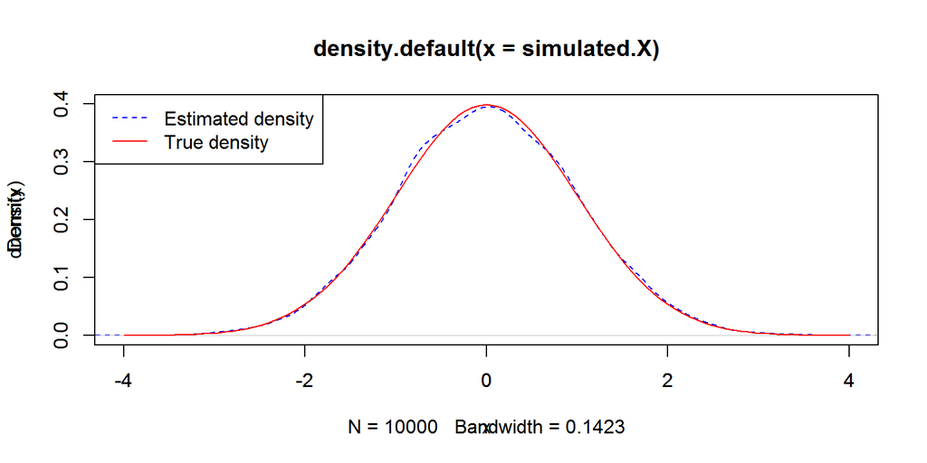

```r
simulated.X = rnorm(n=10000)
dens = density(simulated.X)
plot(dens, col = 'blue', lty = 2, xlim=c(-4,4), ylim=c(0,0.4))
par(new=T)
curve(dnorm,lty=1, col='red',xlim=c(-4,4),ylim=c(0,0.4))
legend(x='topleft',legend=c('Estimated density','True density'),
       col=c('blue','red'),lty=c(2,1))
```

Notice the overlapping axes and axes labels, we want to get rid of them.

A slightly improved plot looks like this:

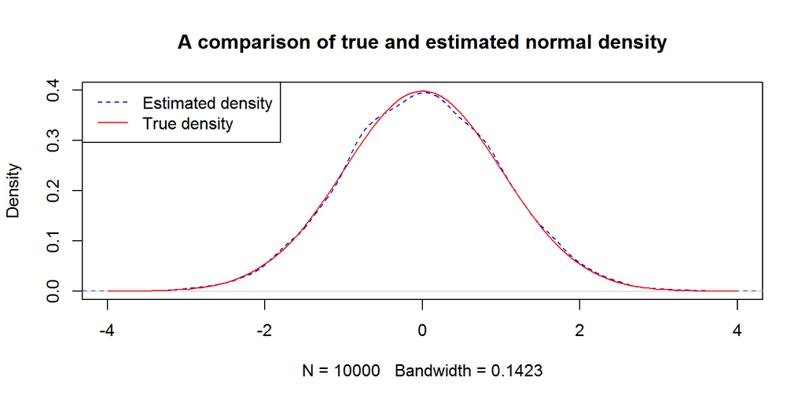

```r
plot(
  dens, col = 'blue', lty = 2, xlim = c(-4,4), ylim = c(0,0.4),
  main = "A comparison of true and estimated normal density"
)
par(new = T)
curve(
  dnorm,lty = 1, col = 'red',xlim = c(-4,4), ylim = c(0,0.4),
  axes = FALSE, xlab = "", ylab = ""
)
legend(
  x = 'topleft',legend = c('Estimated density','True density'),
  col = c('blue','red'), lty = c(2,1)
)
```

It is possible to come up with pretty plots using only base packages. Plotting needs a little practice (and a lot of Googling).

# Data wrangling

In real life (in work), most of our time is spent wrangling with datasets; figuring out how things are recorded, dealing with missing data, extract the useful bits of information from a menagerie of variables. Much less time is spent on actual discovery and trying to draw insights from the datasets. Unfortunate, but most of the time it is the case.

“Most data scientists spend only 20 percent of their time on actual data analysis and 80 percent of their time finding, cleaning, and reorganizing huge amounts of data, which is an inefficient data strategy”

Datasets in classes are mostly curated, clearly annotated. The real world is a lot messier.

The following is an example of real world dataset, still quite well-behaved, but it is closer to what datasets look like out there.

The dataset is adapted from:

[Allison, T. and Chichetti, D. (1976) Sleep in mammals: ecological and constitutional correlates. Science 194 (4266), 732â“734.](http://science.sciencemag.org/content/194/4266/732)

- The dataset consists of animal sleep data with 62 observations on 10 variables.
- Some of the variables are missing.
- The dataset is splitted into two (deliberately): First contains the observation ID plus the first 6 variables. Second contains the observation ID plus the last 4 variables.

We are going to read the datasets, combine them according to their ID, calculate some simple statistics, and visulaize the results.

## Read the dataset into R

Download the datasets sleep1.csv, sleep2.csv here by following the links or download from Github.

Inspect the datasets. Read both files into R.

You should be getting the following header names and data types

```
##        ID   BodyWgt  BrainWgt      NonD     Dream     Sleep      Span
## "integer" "numeric" "numeric" "numeric" "numeric" "numeric" "numeric"
```

```
##        ID      Gest      Pred       Exp    Danger
## "integer" "numeric" "integer" "integer" "integer"
```

## Combine the datasets according to observation ID

You shoud be merging the two datasets where their ID’s match.

The combined headers and data types should look like this:

```
##        ID   BodyWgt  BrainWgt      NonD     Dream     Sleep      Span
## "integer" "numeric" "numeric" "numeric" "numeric" "numeric" "numeric"
##      Gest      Pred       Exp    Danger
## "numeric" "integer" "integer" "integer"
```

*Hint*: Does `cbind` work? Why? What about `merge`?

## Calculate the proportion of dream time in sleep

Notice there is a numeric column “Dream” and a numerical column “Sleep”. We want to calculate the ratio of the two, where neither of them are `NA`’s.

Then append the new column to the dataframe. Call the new Column “Ratio”. The first 10 rows should look like this:

```
##     BodyWgt BrainWgt NonD Dream Sleep Span Gest Pred Exp Danger      Ratio
## 1  6654.000   5712.0   NA    NA   3.3 38.6  645    3   5      3         NA
## 2     1.000      6.6  6.3   2.0   8.3  4.5   42    3   1      3 0.24096386
## 3     3.385     44.5   NA    NA  12.5 14.0   60    1   1      1         NA
## 4     0.920      5.7   NA    NA  16.5   NA   25    5   2      3         NA
## 5  2547.000   4603.0  2.1   1.8   3.9 69.0  624    3   5      4 0.46153846
## 6    10.550    179.5  9.1   0.7   9.8 27.0  180    4   4      4 0.07142857
## 7     0.023      0.3 15.8   3.9  19.7 19.0   35    1   1      1 0.19796954
## 8   160.000    169.0  5.2   1.0   6.2 30.4  392    4   5      4 0.16129032
## 9     3.300     25.6 10.9   3.6  14.5 28.0   63    1   2      1 0.24827586
## 10   52.160    440.0  8.3   1.4   9.7 50.0  230    1   1      1 0.14432990
```

## Boxplot of a variable against another

Now we want to viualize the relationship between the variables “Ratio” and “Danger” using a boxplot.

Try replicate this:

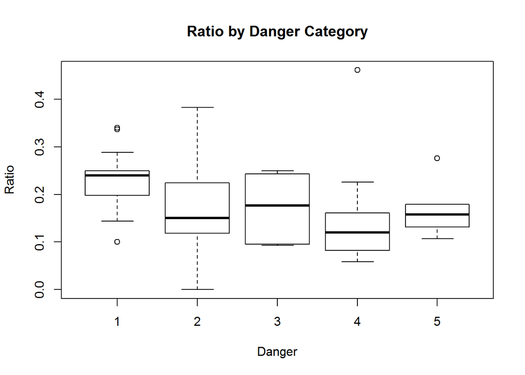

*Tip*: The function `with` can shorten the code significantly for expressions involving dataframes.

`with` creates an environment from the data, so that when you refer to the variables in the dataset, you no longer have refer to the dataset by name.

For example instead of writing

```r
# plot(really_long_dataframe_name$really_long_variable_name_1,
#       really_long_dataframe_name$really_long_variable_name2)
```

you can write

```r
# with(really_long_dataframe_name,
#     plot(really_long_variable_name_1,really_long_variable_name2))
```

See more on `?with`.

## Order the dataset by a variable

What if we want to reorder the dataframe accoring to the variable “Ratio”, in increasing order?

```
##    BodyWgt BrainWgt NonD Dream Sleep Span Gest Pred Exp Danger      Ratio
## 16   3.000    25.00  8.6   0.0   8.6 50.0   28    2   2      2 0.00000000
## 60   4.190    58.00  9.7   0.6  10.3 24.0  210    4   3      4 0.05825243
## 6   10.550   179.50  9.1   0.7   9.8 27.0  180    4   4      4 0.07142857
## 43  10.000   115.00 10.0   0.9  10.9 20.2  170    4   4      4 0.08256881
## 52   3.600    21.00  4.9   0.5   5.4  6.0  225    3   2      3 0.09259259
## 58   2.000    12.30  4.9   0.5   5.4  7.5  200    3   1      3 0.09259259
## 28   1.040     5.50  7.4   0.8   8.2  7.6   68    5   3      4 0.09756098
## 37   0.023     0.40 11.9   1.3  13.2  3.2   19    4   1      3 0.09848485
## 33   0.010     0.25 17.9   2.0  19.9 24.0   50    1   1      1 0.10050251
## 42   0.480    15.50 15.2   1.8  17.0 12.0  140    2   2      2 0.10588235
```

Hint: Does `sort` work? What about `order`?

## Q&A

What’s the difference between `|` (OR) and `||` (OR)?

A: `|` (OR) is bitwise operation. `||` (OR) is not.

```r
A <- c(F,T,F,T,F,T,T,F,T)
B <- c(F,F,T,F,T,F,F,T,F)
A|B
```

```
## [1] FALSE  TRUE  TRUE  TRUE  TRUE  TRUE  TRUE  TRUE  TRUE
```

```r
A||B
```

```
## [1] FALSE
```

Similarly for `&` (AND) and `&&` (AND).

# Introduction to relational databases

- The advantage of using relational databases:
  - Data can be maintained and queried by different threads independently.
  - More efficient queries for objectives that only concerns one subtable.
- Relational database files and their management systems:
  - A .db file is to relational database management systems (SQLite, MySQL, Oracle, etc) as a .pdf file is to PDF readers (Adobe, Foxit, Okular, etc).
  - There is one file format (.db) and many tools (management systems) you can use to manage the file.
  - Different management systems have very similar syntaxes on basic operations and return queried data in very similar forms. They differ in efficiency and other aspects, but not much grammatically.
  - In fact, the commands and even most code lines you learned in this class will run without modification under most management systems.

# Using SQLite in R

- We can work with databases within R by installing related packages.
- Install package RSQLite and connect to a database.

Before you proceed, make sure that you have downloaded baseball.db, and have navigated to the corrected directory that contains the database!

Solutions to the quizes can be found in this R-script.

```r
## Load the RSQLite package (install it first if you haven't yet)
# install.packages("RSQLite", dep=TRUE)
library("RSQLite")
## Make sure the file is under the working directory and then connect to it
driver = dbDriver("SQLite")
conn = dbConnect(driver, "baseball.db")
## Check the tables in a database
dbListTables(conn)
```

```
##  [1] "Allstar"             "AwardsManagers"      "AwardsPlayers"
##  [4] "AwardsShareManagers" "AwardsSharePlayers"  "Batting"
##  [7] "BattingPost"         "Fielding"            "FieldingOF"
## [10] "FieldingPost"        "HOFold"              "HallOfFame"
## [13] "Managers"            "ManagersHalf"        "Master"
## [16] "Pitching"            "PitchingPost"        "Salaries"
## [19] "Schools"             "SchoolsPlayers"      "SeriesPost"
## [22] "Teams"               "TeamsFranchises"     "TeamsHalf"
## [25] "sqlite_sequence"     "xref_stats"
```

```r
## Check the variables in a table
dbListFields(conn, "Teams")
```

```
##  [1] "yearID"         "lgID"           "teamID"         "franchID"
##  [5] "divID"          "Rank"           "G"              "Ghome"
##  [9] "W"              "L"              "DivWin"         "WCWin"
## [13] "LgWin"          "WSWin"          "R"              "AB"
## [17] "H"              "2B"             "3B"             "HR"
## [21] "BB"             "SO"             "SB"             "CS"
## [25] "HBP"            "SF"             "RA"             "ER"
## [29] "ERA"            "CG"             "SHO"            "SV"
## [33] "IPouts"         "HA"             "HRA"            "BBA"
## [37] "SOA"            "E"              "DP"             "FP"
## [41] "name"           "park"           "attendance"     "BPF"
## [45] "PPF"            "teamIDBR"       "teamIDlahman45" "teamIDretro"
```

# SQL commands

- SQL keywords are not case sensitive, but when calling SQL in R, capitalizing key words helps to improve readability.
- SQL is designed mainly for extracting data from databases, NOT for analyzing them. SQL provides basic summarizing commands and tools, but do not expect too much. We can use R for further analysis.

### Basic SQL commands

The very basic form of SQL queries is:

```
## Pseudo-code
## Required clauses
SELECT ColumnNames
FROM TableName
## Optional clauses
WHERE Conditions
GROUP BY VariableNames HAVING Conditions
ORDER BY VariableNames
```

In **SELECT**:

- **AS** renames the extracted variables for convenience. It is especially useful when a. they are summarized; or b. (will see later) when they have to come with prefixes like table names.
- **AS** can often be omitted. Thus the variable name should NOT contain space (Why?).
- Aggregate functions. For a list, check, for example, http://www.techonthenet.com/sql_server/functions/index_alpha.php.

```
## Pseudo-code: SQLite
SELECT Var1, MIN(Var2) AS MinVar2, AVG(Var3) AS AvgVar3
FROM TableName
```

In **FROM**:

- In this course, unless when combining tables, we only select from one table.

In **WHERE**:

- If there are multiple conditions, they should be connected by logical connectives (**AND**, **OR** and parenthesis when needed). Conditions can also be decorated by other logical operators (**NOT**, etc). For a list of logical operators in SQL, see http://www.w3resource.com/sql/boolean-operator/sql-boolean-operators.php.

```
## Pseudo-code: SQLite
## Example from: http://beginner-sql-tutorial.com/sql-logical-operators.htm
SELECT first_name, last_name, age, games
FROM student_details
WHERE age >= 10 AND age <= 15 OR NOT games = 'Football'
```

**Quiz 1:** Extract data from table *Master*. Generate a table with all variables in Master for players born in 1980s and sort by their names.

```
# Solution: see laqsql.R
```

For **GROUP BY**

- **GROUP BY** is used in combination with aggregate functions in **SELECT**.
- (From Wikipedia) **HAVING** modifies **GROUP BY**. It is indispensable because **WHERE** does not allow aggregate functions.

```
## Pseudo-code: SQLite
## Example from: https://en.wikipedia.org/wiki/Having_(SQL)
SELECT DeptID, SUM(SaleAmount)
FROM Sales
WHERE SaleDate = '01-Jan-2000'
GROUP BY DeptID
HAVING SUM(SaleAmount) > 1000
```

**Quiz 2:** Query data from table *Teams*. Generate a table showing the number of teams that won more than half of the games each year since 1950. Sort by year.

```
# Solution: see Lab4.R
```

## Inner joining tables

Look at the nice visualization from https://www.w3schools.com/sql/sql_join_inner.asp.

Basic form (not quite “basic”, careful):

```
## Pseudo-code
SELECT T1.ColumnNames, T2.ColumnNames
FROM T1 INNER JOIN T2 ON JoiningConditions
## Other clauses
WHERE Conditions
## etc
```

- What are the different roles of Table “T1” and Table “T2”?
- **ON**: Specify which rows to combine from the two tables
- In **SELECT** here: specify table names as prefixes for variable names when needed.

**Example:**

```
SELECT Schools.schoolID, schoolName, schoolCity, schoolState, playerID
FROM Schools INNER JOIN SchoolsPlayers ON Schools.schoolID = SchoolsPlayers.schoolID
WHERE schoolState = 'MI'
```

- If we omit “Schools” in the first “Schools.schoolID”, there will be an error.
- In general, DO NOT omit table names if causing ambiguity.

**Quiz 3:** Join table *Schools* with table *SchoolsPlayers*. Generate a table showing the number of players from each school in Michigan. Sort by the number of players in decreasing order.

```
# Solution: see Labsql.R
```

# Extras

##### - See this stackoverflow post on [when to use r when to use sql](http://stackoverflow.com/questions/9795051/when-to-use-r-when-to-use-sql).

##### - See this Quora post on [how do we deal with very large datasets that do not fit into RAM](https://www.quora.com/How-do-we-deal-with-very-large-datasets-that-do-not-fit-into-RAM).

[figure not shown]

# Q&A

#### What’s the difference between `WHERE` and `HAVING`?

See this post here (http://stackoverflow.com/questions/287474/whats-the-difference-between-having-and-where).

`HAVING` is used to check conditions after the aggregation takes place.

`WHERE` is used before the aggregation takes place.

In the case of quiz 2 above, it makes no difference (restriction on `yearID` can take place before or after `GROUP BY`). But in the cases where you want you restrict the output by the grouped results, you should stick to `HAVING`.

.